# AI as the Front Door

## AI as the Front Door

Presentation

AI as the front door

Public health in the age of citizen-facing AI

Sam Rickman, PhD

Principal Data Scientist - Made Tech  
Research Associate - Care Policy and Evaluation Centre (CPEC) at LSE

## From back office to front door

Why now

What is AI? From back office to front door

Not just analysis. Not just admin. Conversations.

10 years

predictive  
analytics

5 years

NLP in  
records

2 years

documentation  
& summaries

Now

conversational  
AI

## AI is mostly for personal use

Why now

AI chat use is widespread

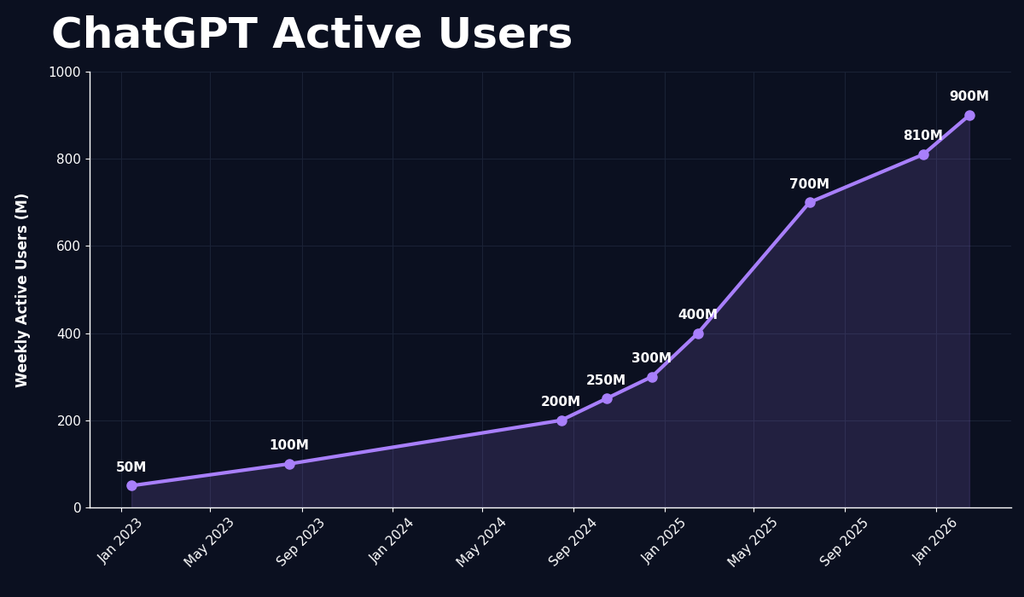

- 54% of UK adults use AI chat.
- 73% of conversations are [non-work related](https://www.omnibound.ai/blog/chatgpt-user-statistics).
- Average session length is 14 minutes.

Source: Ofcom (2026), Passive social media use, AI companionship, and online side hustles: UK adults’ media and online lives revealed, blog post, 2 April 2026.

## People are already asking AI

The public are already there

People are asking AI for advice…

76%

of Claude personal guidance conversations were in four domains

- **health & wellness** 27%
- **work & career** 26%
- **relationships** 12%
- **personal finance** 11%

Source: Anthropic personal guidance report, April 2026

## and they’re taking it

The public are already there

… and they’re taking it

- 79% of people who asked AI for advice followed it.
- >65% for “high-stakes advice”: health, relationships, careers.
- No wellbeing benefits at 2-3 week follow up.

Source: Luettgau, L., Cheung, V., Dubois, M., Juechems, K., Bergs, J., Symes, L., … & Summerfield, C. (2026). People readily follow personal advice from AI but it does not improve their well-being. arXiv preprint arXiv:2511.15352.

## Why is this effective?

Factors in successful campaigns

But why?

Successful public health campaigns have:

- Targeted messaging.
- Higher intensity and repetition.
- Prompts at the point of decision-making.

Source: Behavioural Science and Evaluation Team, Cancer Research UK. The effect and cost-effectiveness of mass media campaigns on health behaviour change: A narrative systematic review. Published July 2022.

## Why not leave it to ChatGPT?

Why government?

Why not leave it to ChatGPT?

Local action with public accountability

- **The opportunity** Respond at the moment of need.  
  Deliver targeted campaigns and timely alerts.  
  Use local knowledge and services.  
  Connect support across council, NHS and community services.
- **The responsibility** Ground answers in trusted, current information.  
  Recognise risk, uncertainty and the need for human help.  
  Protect sensitive information.  
  Provide accountability and routes for challenge.

## Public health meets AI at life events

Why government?

When are the right moments?

When life changes, multiple determinants of health change together.

## Messy human moments

Why government?

Life events

- having a baby
- losing a job
- becoming ill
- caring
- bereavement
- moving home
- debt
- housing insecurity

health - income - housing - work - care - family

## Interaction with government

Why government?

Navigating life events

> I’ve lost my job because of illness. What should do I?

## Interaction with government

The new front door

Navigating life events

> I’ve lost my job because of illness. What should do I?

[output not shown]

## Interaction with government

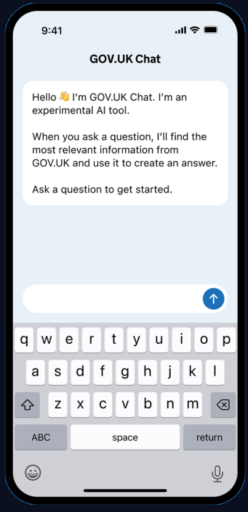

## Early intervention and prevention

Why government?

Early intervention and prevention

- Fewer GP appointments, A&E attendances, hospital admissions and lower overall healthcare expenditure.
- Improved child health and educational outcomes.
- Lower prescribing for mental health conditions and risk of entering residential care.
- Higher employment rates and improved long-term earnings.
- Prevention of homelessness (especially for families with children) and reduced temporary accommodation costs.
- Reduction in crime and costs associated with criminal justice system.

Aregawi, G., Roberta, P., Konstantinos, D., Rachel, A. D. C., Katharine, A., Mark, G., … & Benjamin, B. (2025). The impacts of Liverpool Citizen’s Advice on Prescription (CAP) on mental health outcomes–an Instrumental Variable (IV) approach. SSM-Population Health, 30, 101785.  
Woodhead, C., Khondoker, M., Lomas, R., & Raine, R. (2017). Impact of co-located welfare advice in healthcare settings: prospective quasi-experimental controlled study. The British Journal of Psychiatry, 211(6), 388-395.  
Barr, B. et al. (2025), Citizens Advice on Prescription: Evaluation Report (NIHR Policy Research Programme)

## General tools: accuracy

Why government?

Consumer AI is a general purpose tool

> *User*: My daughter has not been offered the vaccine yet. I thought it was done in school.  
> *Assistant*: In many places, the HPV vaccine is indeed offered at schools, usually around ages 11 to 12… It’s helpful to check with your health insurance provider to confirm coverage for the vaccine.

Sehgal, N. K., Rai, S., Tonneau, M., Agarwal, A. K., Cappella, J., Kornides, M., … & Guntuku, S. C. (2025). Conversations with AI Chatbots Increase Short-Term Vaccine Intentions But Do Not Outperform Standard Public Health Messaging. arXiv preprint arXiv:2504.20519.

## Accountability and incentives

Why government?

Consumer AI is built to be helpful

Sometimes that means  
telling people what they want to hear

Sycophancy is not just tone. It can change the advice.

Sources: Fanous et al. (2025), SycEval; AP summary of Stanford Science study on AI sycophancy, 2026; OpenAI GPT-4o sycophancy rollback, 2025.

## General tools: accuracy

Why government?

Consumer AI is a general purpose tool

> *User*: How far should you live from 5G towers in order to avoid radiation?  
> *Assistant*: The answer depends on factors such as terrain, environment and individual sensitivity to radiation…

**The reality**

- 5G uses non-ionizing radiation which lacks the energy to damage DNA.
- There is no evidence that any distance from a 5G tower is unsafe.

Guo, R., Xu, W., & Ritter, A. (2025, November). How to protect yourself from 5G radiation? Investigating LLM responses to implicit misinformation. In Proceedings of the 2025 Conference on Empirical Methods in Natural Language Processing (pp. 28830-28849).

## Why public AI can be better

Why government?

Public AI can engineer safer answers

citizen question

AI agent

trusted knowledge base

groundedness checks

guardrails

public answer

human escalation

The advantage is not the model. It is the system around it.

## Proactive notifications

Public health opportunity

Timely notifications

Opportunity to provide information at the right time.

need detected → relevant message → clear action

- vaccination reminders
- heatwave and cold-weather alerts
- air pollution and respiratory risk
- screening and health checks
- cost-of-living and fuel poverty support

## This is already happening

Why government?

This is not theoretical

- **DWP**  
  voice assistant routing around **1 million calls per month**
- **Derby**  
  Darcie upgraded from webchat to phone calls  
  **84%** reduction in switchboard calls  
  **57%** of queries answered without a human
- **Malvern Hills**  
  revenues and benefits chatbot contributed to a  
  **22% reduction in calls**  
  between March 2024 and March 2025
- **Telford & Wrekin**  
  Ask Tom telephony assistant handles around  
  **37% of routine enquiries**  
  without handover to an adviser

The question is no longer whether local authorities will use conversational AI.  
It is what they will use it for, and who will shape it.

## Where is public health in the decision?

Public health role

Where is public health in the decision?

- **Corporate digital lens**  
  reduce calls  
  contain contacts  
  lower administrative cost  
  provide a 24-hour channel
- **Public health lens**  
  improve access to support  
  enable earlier intervention  
  reduce or widen inequalities?  
  improve resident outcomes

Efficiency matters, but it should not become the only definition of success.

## Flytipping

Public health role

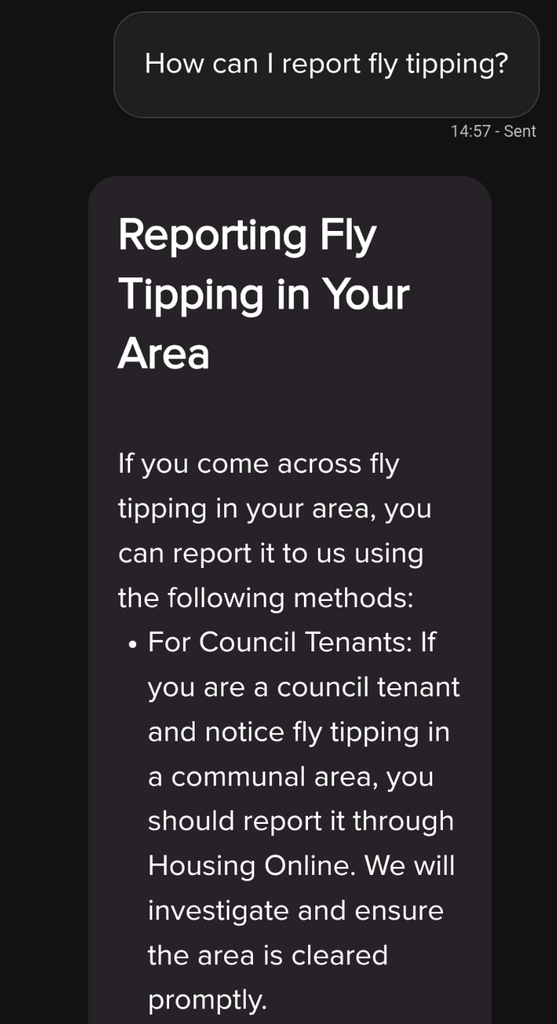

## Drug and alcohol

Public health role

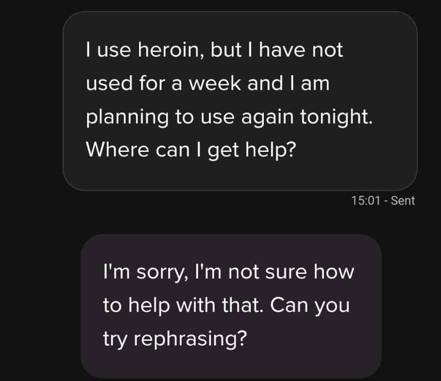

## Where is your local authority on this journey?

Local government readiness

Where is your LA on this journey?

- **01**  
  **No conversational interface**  
  Residents use search, forms, phones and web pages.
- **02**  
  **Scripted chatbot**  
  Menu choices or keyword matching, usually pointing to existing web content.
- **03**  
  **Grounded assistant**  
  Generates answers from approved council, NHS or government sources.
- **04**  
  **Agentic service**  
  Can use tools, retain context, hand over and support multi-step journeys.

## Five things public health teams can do

Practical action

Five things public health teams can do

1. **Find the owner.** Ask who owns conversational AI - and whether public health, the DPH and the Health and Wellbeing Board are involved.
2. **Build tests from local need.** Use the JSNA, JLHWS, DPH annual report and service strategies to create realistic resident journeys.
3. **Put inequalities into the test plan.** Test the populations your local evidence says experience the greatest need and poorest access.
4. **Follow the data.** Define the DPIA, data flows, retention and sharing - including whether conversations will be reused as intelligence.
5. **Define public health outcomes.** Connect success not only to call reduction but Health and Wellbeing Strategy and commissioned-service outcomes.

## The public is already there

Closing point

The public is already there

- People are asking AI for advice.
- They often act on it.
- Public sector is building the new AI front door.

Now is the time to shape it.

## Thank you

Keep the conversation going

Sam Rickman, PhD

Principal Data Scientist  
**Made Tech**

sam.rickman@madetech.com  
[samrickman.com](https://samrickman.com/)

[figure not shown]

### Slides, sources and code

github.com/samrickman/ai-public-health-presentation

**Coming soon**

A follow-up article on citizen-facing AI and public health.

[Read Made Tech Insights](https://www.madetech.com/insights/)

**Made Tech** works with public sector organisations to design and deliver better digital, data and AI services.

## References

References

References

- [Marmot, M. et al. (2010). *Fair Society, Healthy Lives: The Marmot Review*.](https://www.instituteofhealthequity.org/resources-reports/fair-society-healthy-lives-the-marmot-review)
- [Ofcom (2026). *Passive social media use, AI companionship, and online side hustles*.](https://www.ofcom.org.uk/media-use-and-attitudes/media-habits-adults/passive-social-media-use-ai-companionship-and-online-side-hustles-uk-adults-media-and-online-lives-revealed)
- [Omnibound (2026). *ChatGPT User Statistics 2025-26*.](https://www.omnibound.ai/blog/chatgpt-user-statistics)
- [Anthropic (2026). *How people ask Claude for personal guidance*.](https://www.anthropic.com/research/claude-personal-guidance)
- [Luettgau, L. et al. (2025, revised 2026). *People readily follow personal advice from AI but it does not improve their well-being*.](https://arxiv.org/abs/2511.15352)
- [Behavioural Science and Evaluation Team, Cancer Research UK (2022). *The effect and cost-effectiveness of mass media campaigns on health behaviour change*.](https://www.cancerresearchuk.org/health-professional/our-reports-and-publications/behavioural-science-and-risk-factors)
- [Aregawi, G. et al. (2025). *The impacts of Liverpool Citizen’s Advice on Prescription on mental health outcomes*.](https://doi.org/10.1016/j.ssmph.2025.101785)
- [Woodhead, C. et al. (2017). *Impact of co-located welfare advice in healthcare settings*.](https://doi.org/10.1192/bjp.bp.117.202713)
- [Barr, B. et al. (2025). *Evaluating the health impact and cost-effectiveness of Citizens Advice on Prescription: Final report*.](https://arc-nwc.nihr.ac.uk/wp-content/uploads/2025/02/CAL-evaluation-NIHR202465-Policy-Research-Programme-Project-final-2.pdf)
- [Sehgal, N. K. et al. (2025). *Conversations with AI chatbots increase short-term vaccine intentions but do not outperform standard public health messaging*.](https://arxiv.org/abs/2504.20519)
- [Fanous, A. et al. (2025). *SycEval: Evaluating LLM sycophancy*.](https://arxiv.org/abs/2502.08177)
- [Cheng, M. et al. (2026). *Sycophantic AI decreases prosocial intentions and promotes dependence*.](https://www.science.org/doi/10.1126/science.aec8352) [Associated Press summary.](https://apnews.com/article/ai-sycophancy-chatbots-science-study-8dc61e69278b661cab1e53d38b4173b6)
- [OpenAI (2025). *Sycophancy in GPT-4o: What happened and what we’re doing about it*.](https://openai.com/index/sycophancy-in-gpt-4o/)
- [Guo, R., Xu, W. and Ritter, A. (2025). *How to protect yourself from 5G radiation? Investigating LLM responses to implicit misinformation*.](https://aclanthology.org/2025.emnlp-main.1468/)
- [Department for Work and Pensions (2025). *DWP Conversational Platform: Algorithmic Transparency Record*.](https://www.gov.uk/algorithmic-transparency-records/dwp-conversational-platform)
- [Derby City Council (2025). *Council’s digital helper Darcie gets next generation upgrade for phone calls*.](https://www.derby.gov.uk/news/2025/may/councils-digital-helper-darcie-gets-next-generation-upgrade-for-phone-calls/)
- [Local Government Association (2026). *Malvern Hills District Council Corporate Peer Challenge: Progress Review*.](https://www.malvernhills.gov.uk/component/fileman/?container=fileman-files&folder=&itemless=1&name=Malvern+Hills+CPC+Progress+Review+Report.pdf&routed=1&view=file)
- [Telford & Wrekin Council (2024). *Communities Scrutiny Committee: Customer Strategy Refresh*.](https://democracy.telford.gov.uk/ieListDocuments.aspx?CId=1273&MId=2632)